# Evaluations of positive and negative stimuli using the Affective Misattribution Procedure (AMP) and self-reports

Analysis

Template: Ian Hussey; content: [Student name]

27 November, 2023

# Dependencies

```r
library(tidyverse)
library(knitr)
library(kableExtra)
library(janitor)
library(scales)
```

# Data

Load the processed data and apply the global exclusions.

```r
data_processed <- read_csv("../data/processed/data_processed.csv")

data_processed_after_exclusions <- data_processed |>
  filter(exclude_participant == "include")
```

# Sample descriptives

## Sample size before exclusions

```r
data_processed |>
  count(name = "n") |>
  kable() |>
  add_header_above(header = c("Whole sample" = 1)) |> # note that you can add header rows to tables like this. The "1" indicates the number of columns the header should span. The sum of these numbers must equal the number of columns or you'll get an error.
  kable_classic(full_width = FALSE)
```

| Whole sample n |
| --- |
| 102 |

## Sample size after exclusions

Sample used in subsequent analyses

```r
data_processed_after_exclusions |>
  count(name = "n") |>
  kable() |>
  add_header_above(header = c("For analysis" = 1)) |>
  kable_classic(full_width = FALSE)
```

| For analysis n |
| --- |
| 90 |

## Age

```r
data_processed_after_exclusions |>
  mutate(age = as.numeric(age)) |>
  summarise(Mean = mean(age, na.rm = TRUE),
            SD = sd(age, na.rm = TRUE)) |>
  mutate_all(.funs = janitor::round_half_up, digits = 1) |>
  kable() |>
  add_header_above(header = c("Age" = 2)) |>
  kable_classic(full_width = FALSE)
```

| Age Mean | Age SD |
| --- | --- |
| 36.8 | 12.4 |

## Gender

```r
data_processed_after_exclusions |>
  rename(Gender = gender) |>
  group_by(Gender) |>
  summarise(n = n()) |>
  mutate(Percent = paste0(round_half_up((n / sum(n)) * 100, 1), "%")) |>
  mutate(Gender = stringr::str_to_sentence(Gender)) |> # Change the case of the Gender variable so that it prints nicely
  kable() |>
  kable_classic(full_width = FALSE)
```

| Gender | n | Percent |
| --- | --- | --- |
| Female | 39 | 43.3% |
| Male | 48 | 53.3% |
| Nonbinary | 3 | 3.3% |

# Descriptives

Descriptive statistics and plots of the measures (excluding the demographics variables)

## Self-reported evaluations

### Descriptive stats

```r
# overall self-reported evaluations
dat_mean_ratings <- data_processed_after_exclusions |>
  summarise(Mean = mean(mean_evaluation, na.rm = TRUE),
            SD = sd(mean_evaluation, na.rm = TRUE),
            n = n()) |>
  mutate(group = "Full sample")

# self-reported evaluations by gender category
dat_mean_ratings_by_gender <- data_processed_after_exclusions |>
  group_by(group = gender) |>
  summarise(Mean = mean(mean_evaluation, na.rm = TRUE),
            SD = sd(mean_evaluation, na.rm = TRUE),
            n = n())

# combine both into one table
bind_rows(dat_mean_ratings,
          dat_mean_ratings_by_gender) |>
  select(Subset = group, Mean, SD, n) |> # select variables of interest, and rename one
  mutate(Subset = stringr::str_to_sentence(Subset)) |> # Change the case of the Subset variable so that it prints nicely
  mutate_if(is.numeric, round_half_up, digits = 2) |>
  kable() |>
  add_header_above(header = c(" " = 1, "Self-reported evaluations" = 3)) |>
  kable_classic(full_width = FALSE)
```

| Subset | Self-reported evaluations Mean | Self-reported evaluations SD | Self-reported evaluations n |
| --- | --- | --- | --- |
| Full sample | 1.64 | 1.02 | 90 |
| Female | 1.32 | 0.71 | 39 |
| Male | 1.81 | 1.03 | 48 |
| Nonbinary | 3.33 | 2.19 | 3 |

### Descriptive plot

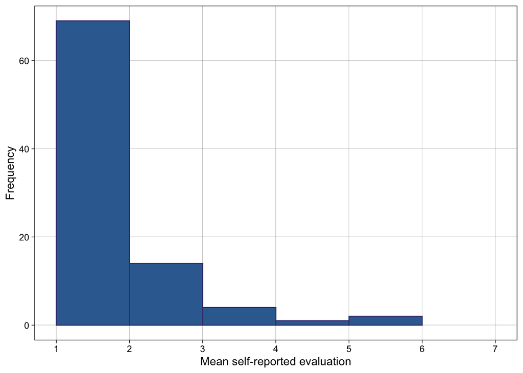

```r
ggplot(data_processed_after_exclusions, aes(x = mean_evaluation)) +
  geom_histogram(binwidth = 1,
                 boundary = 0,
                 fill = viridis_pal(begin = 0.45, option = "mako")(1),
                 color = viridis_pal(begin = 0.30, option = "mako")(1)) +
  xlab("Mean self-reported evaluation") +
  ylab("Frequency") +
  theme_linedraw() +
  scale_x_continuous(breaks = pretty_breaks(n = 7)) +
  coord_cartesian(xlim = c(1, 7)) +
  theme(panel.grid.minor = element_blank())
```

## AMP evaluations

### Descriptive stats

add table of means, SDs, Ns

```r
# overall self-reported evaluations
dat_amp_ratings <- data_processed_after_exclusions |>
  summarise(Mean = mean(AMP_score, na.rm = TRUE),
            SD = sd(AMP_score, na.rm = TRUE),
            n = n()) |>
  mutate(group = "Full sample")

# self-reported evaluations by gender category
dat_amp_ratings_by_gender <- data_processed_after_exclusions |>
  group_by(group = gender) |>
  summarise(Mean = mean(AMP_score, na.rm = TRUE),
            SD = sd(AMP_score, na.rm = TRUE),
            n = n())

# combine both into one table
bind_rows(dat_amp_ratings,
          dat_amp_ratings_by_gender) |>
  select(Subset = group, Mean, SD, n) |> # select variables of interest, and rename one
  mutate(Subset = stringr::str_to_sentence(Subset)) |> # Change the case of the Subset variable so that it prints nicely
  mutate_if(is.numeric, round_half_up, digits = 2) |>
  kable() |>
  add_header_above(header = c(" " = 1, "Self-reported evaluations" = 3)) |>
  kable_classic(full_width = FALSE)
```

| Subset | Self-reported evaluations Mean | Self-reported evaluations SD | Self-reported evaluations n |
| --- | --- | --- | --- |
| Full sample | 0.58 | 0.19 | 90 |
| Female | 0.58 | 0.21 | 39 |
| Male | 0.58 | 0.18 | 48 |
| Nonbinary | 0.55 | 0.06 | 3 |

### Descriptive plots

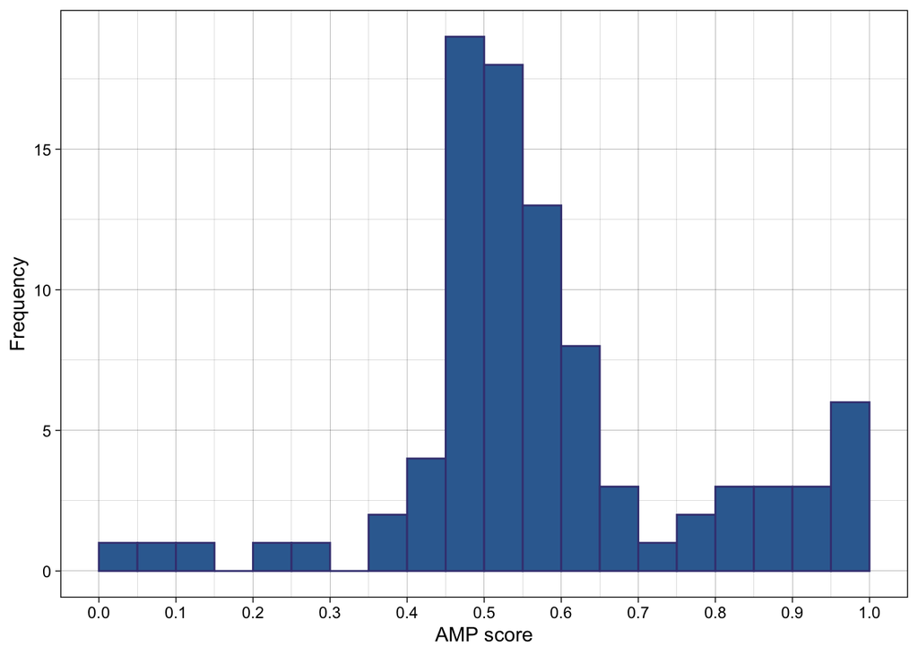

```r
ggplot(data_processed_after_exclusions, aes(x = AMP_score)) +
  geom_histogram(binwidth = 0.05,
                 boundary = 0,
                 fill = viridis_pal(begin = 0.45, option = "mako")(1),
                 color = viridis_pal(begin = 0.30, option = "mako")(1)) +
  xlab("AMP score") +
  ylab("Frequency") +
  theme_linedraw() +
  scale_x_continuous(breaks = pretty_breaks(n = 10))
```

# Analyses & hypothesis tests

## Self-reported evaluations are correlated with evaluations on the AMP

### Plot

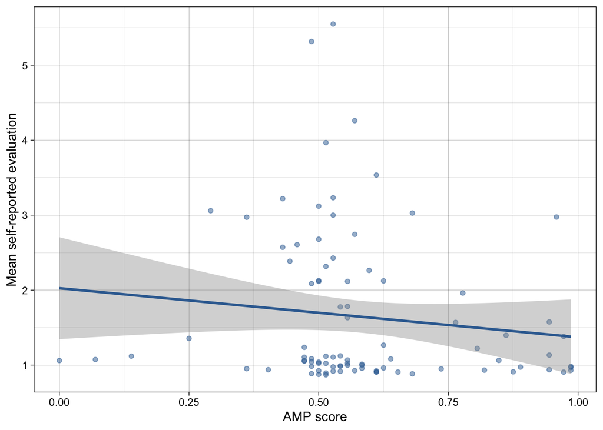

```r
ggplot(data_processed_after_exclusions,
       aes(x = AMP_score,
           y = mean_evaluation)) +
  geom_jitter(color = viridis_pal(begin = 0.45, option = "mako")(1),
              alpha = 0.5) +
  geom_smooth(method = "lm",
              color = viridis_pal(begin = 0.45, option = "mako")(1)) +
  xlab("AMP score") +
  ylab("Mean self-reported evaluation") +
  theme_linedraw()
```

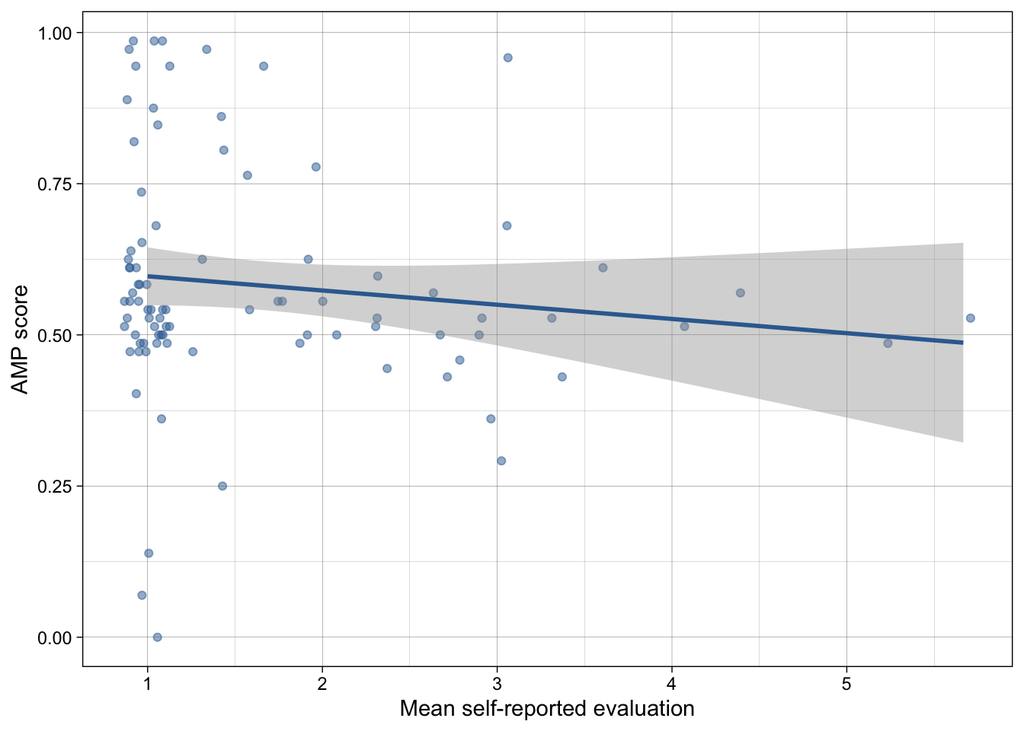

```r
ggplot(data_processed_after_exclusions,
       aes(y = AMP_score,
           x = mean_evaluation)) +
  geom_jitter(color = viridis_pal(begin = 0.45, option = "mako")(1),
              alpha = 0.5) +
  geom_smooth(method = "lm",
              color = viridis_pal(begin = 0.45, option = "mako")(1)) +
  ylab("AMP score") +
  xlab("Mean self-reported evaluation") +
  theme_linedraw()
```

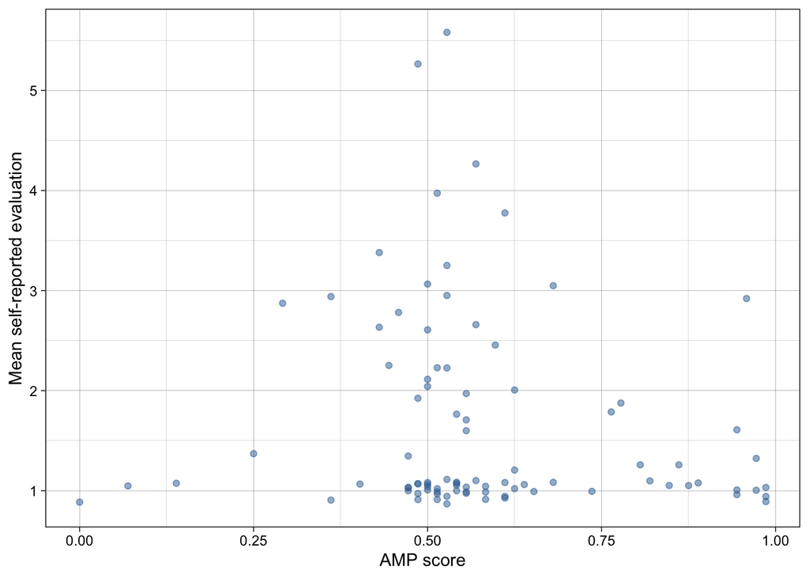

```r
ggplot(data_processed_after_exclusions,
       aes(x = AMP_score,
           y = mean_evaluation)) +
  geom_jitter(color = viridis_pal(begin = 0.45, option = "mako")(1),
              alpha = 0.5) +
  xlab("AMP score") +
  ylab("Mean self-reported evaluation") +
  theme_linedraw()
```

More complex plots:

#### Axial histograms

Scatter plots with axial histograms using ggExtra: https://cran.r-project.org/web/packages/ggExtra/vignettes/ggExtra.html

add axial histograms to a scatter plot. Split both the scatter plot and the histograms by gender.

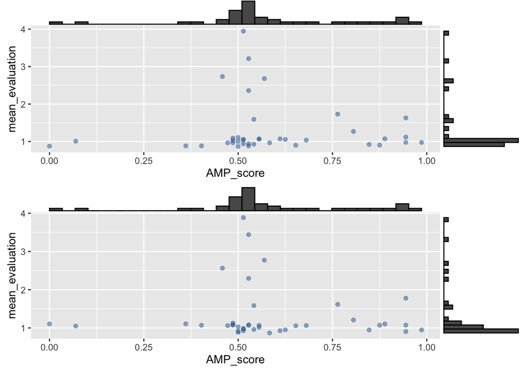

```r
data_female <- subset(data_processed_after_exclusions, gender == "female")
data_male <- subset(data_processed_after_exclusions, gender == "male")

p_female <- ggplot(data_female,
       aes(x = AMP_score,
           y = mean_evaluation)) +
  geom_jitter(color = viridis_pal(begin = 0.45, option = "mako")(1),
              alpha = 0.5)

p_male <- ggplot(data_female,
       aes(x = AMP_score,
           y = mean_evaluation)) +
  geom_jitter(color = viridis_pal(begin = 0.45, option = "mako")(1),
              alpha = 0.5)

p_male_hist <- ggExtra::ggMarginal(p_male, type = "histogram")
p_female_hist <- ggExtra::ggMarginal(p_female, type = "histogram")

gridExtra::grid.arrange(p_male_hist, p_female_hist, ncol = 1)
```

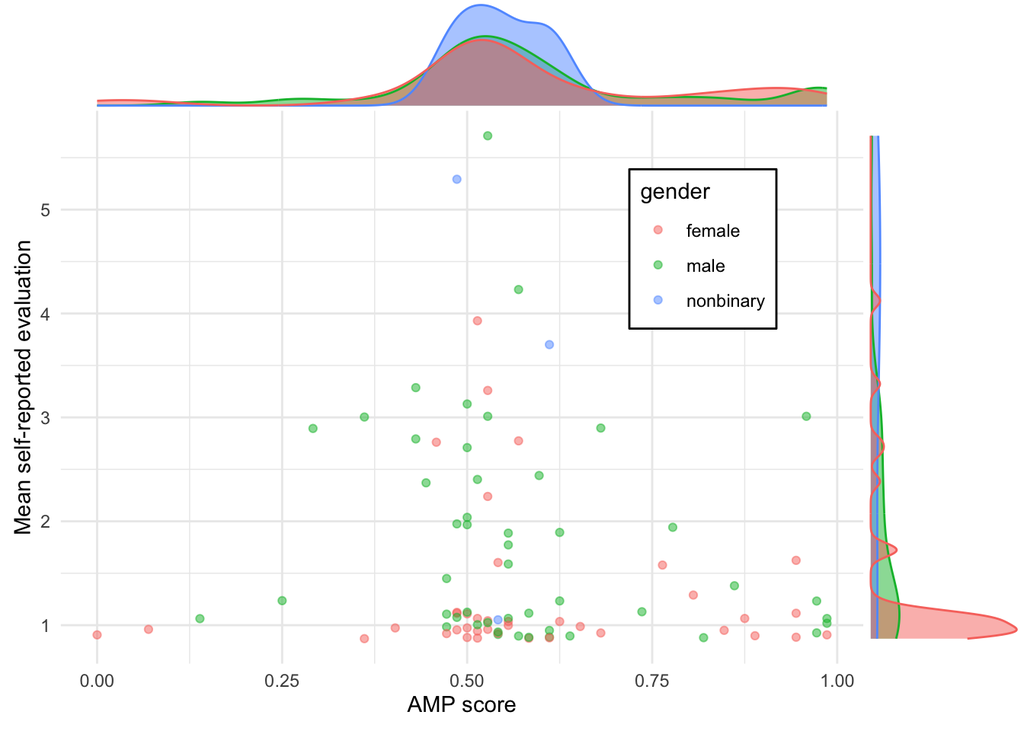

```r
p1 <- ggplot(data_processed_after_exclusions,
       aes(x = AMP_score,
           y = mean_evaluation,
           colour = gender)) +
    geom_jitter(alpha = 0.5) +
  xlab("AMP score") +
  ylab("Mean self-reported evaluation") +
  theme_minimal() +
  theme(legend.position = c(0.8, 0.75),
        legend.background = element_rect(fill = "white", colour = "black"))

  ggExtra::ggMarginal(p1, groupColour = TRUE, groupFill = TRUE)
```

#### Labelled points

Label points using ggrepel: https://cran.r-project.org/web/packages/ggrepel/vignettes/ggrepel.html

Label the points in a scatter plot using their participant codes. Label only the participants with more extreme scores.

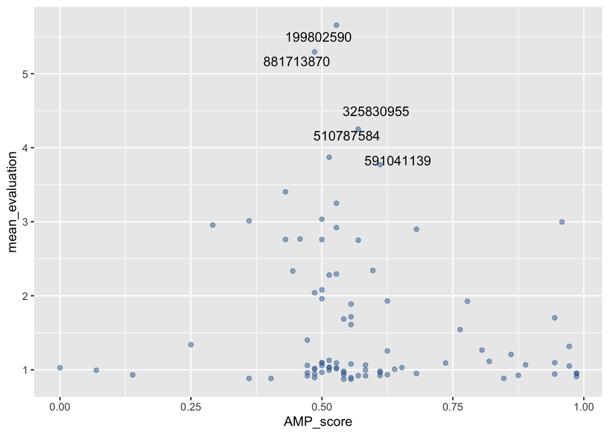

```r
library(ggrepel)

# Berechnen der 95. Perzentile für AMP_score und mean_evaluation
quantile_95_mean_evaluation <- quantile(data_processed_after_exclusions$mean_evaluation, 0.95)


# Filtern der Daten für Werte im 95. Perzentil
extreme_values <- data_processed_after_exclusions |>
  filter(mean_evaluation >= quantile_95_mean_evaluation)

ggplot(data_processed_after_exclusions,
          aes(x = AMP_score,
              y = mean_evaluation,
              label = subject)) +
geom_jitter(color = viridis_pal(begin = 0.45, option = "mako")(1),
            alpha = 0.5) +
  geom_text_repel(data = extreme_values,
                  aes(label = subject),
                  box.padding = 0.35,
                  point.padding = 0.5,
                  segment.color = 'grey50')
```

#### Magnify areas

Magnify areas of your plot with ggmagnify: https://hughjonesd.github.io/ggmagnify/

Magnify an area of one of your scatter plots, eg where there are a lot of data points in a small area.

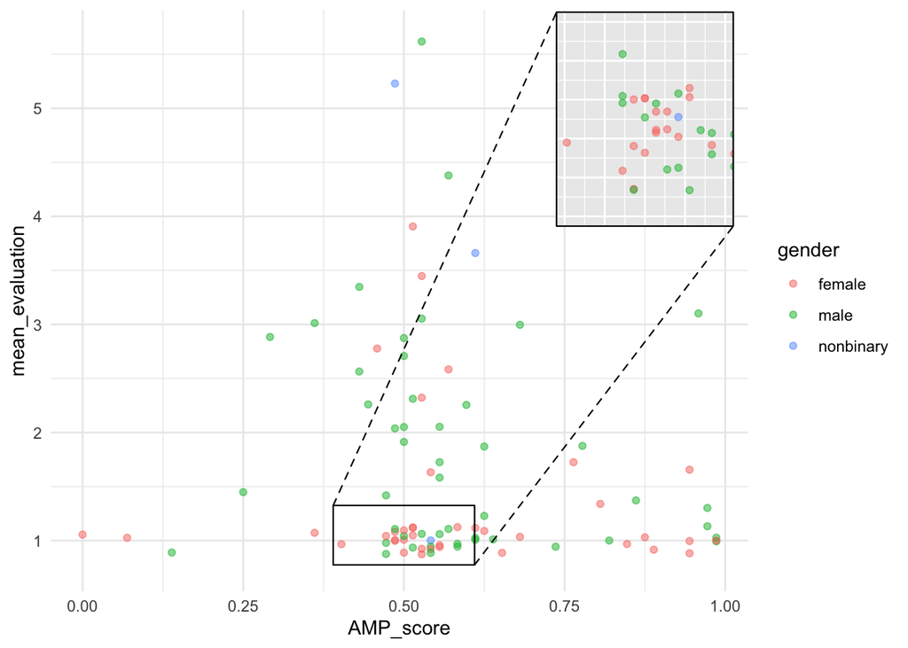

```r
library(ggmagnify)

p2 <- ggplot(data_processed_after_exclusions,
       aes(x = AMP_score,
           y = mean_evaluation,
           colour = gender)) +
  geom_jitter(alpha = 0.5) +
  geom_magnify(shape = "rect",
               from = c(xmin = 0.4, xmax = 0.6, ymin = 0.8, ymax = 1.3 ),
               to = c(xmin = 0.75, xmax = 1, ymin = 4, ymax = 5.8 )) +
  theme_minimal()

p2
```

### Test

run an appropriate test. Below the output, interpret the results: write a few sentences that report and interpret the results following APA reporting style.

```r
cor.test(data_processed_after_exclusions$AMP_score, data_processed_after_exclusions$mean_evaluation,
         method = "pearson")
```

```
##
##  Pearson's product-moment correlation
##
## data:  data_processed_after_exclusions$AMP_score and data_processed_after_exclusions$mean_evaluation
## t = -1.1742, df = 88, p-value = 0.2435
## alternative hypothesis: true correlation is not equal to 0
## 95 percent confidence interval:
##  -0.32298009  0.08508347
## sample estimates:
##       cor
## -0.124196
```

there is a small negativ correlation between the AMP-Score and the evaluation mean. This correlation is not significant.

## Self-reported evalautions differ between men and women

### Plot

split histogram, split violin plot, raincloud plot, etc.

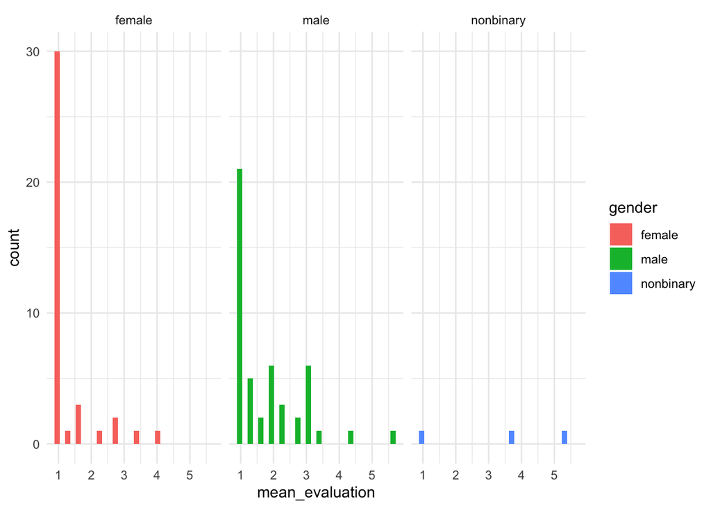

```r
ggplot(data_processed_after_exclusions,
       aes(x = mean_evaluation,
           fill = gender)) +
  geom_histogram() +
  facet_grid(~ gender) +
  theme_minimal()
```

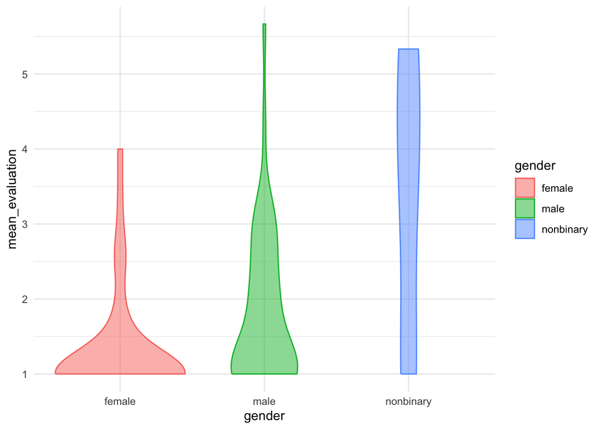

```r
ggplot(data_processed_after_exclusions,
       aes(y = mean_evaluation,
           x = gender,
           fill = gender,
           color = gender)) +
  geom_violin(alpha = 0.5, size = 0.5) +
  theme_minimal()
```

### Test

```r
filtered_data <- data_processed_after_exclusions |>
  filter(gender %in% c("male", "female"))

ttest_mean.eval_gender <- t.test(mean_evaluation ~ gender, data = filtered_data)
```

### Plot

split histogram, split violin plot, raincloud plot, etc.

This time, vary the labeling and order of the legend, e.g., capitalise “Men” and “Women”, and know how to change the order of the factors.

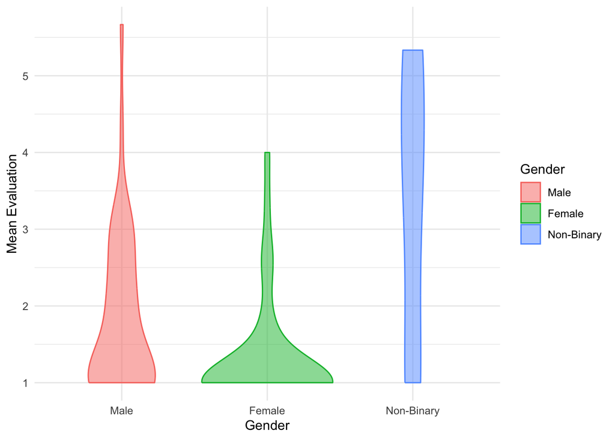

```r
ggplot(data_processed_after_exclusions,
       aes(y = mean_evaluation,
           x = gender,
           fill = gender,
           color = gender)) +
  geom_violin(alpha = 0.5, size = 0.5) +
  scale_x_discrete(limits = c("male", "female", "nonbinary")) +
  scale_x_discrete(limits = c("male", "female", "nonbinary"),
                   labels = c("Male", "Female", "Non-Binary")) +
  scale_fill_discrete(limits = c("male", "female", "nonbinary"),
                      name = "Gender",
                      labels=c("Male", "Female", "Non-Binary")) +
  scale_color_discrete(limits = c("male", "female", "nonbinary"),
                       name = "Gender", labels=c("Male", "Female", "Non-Binary")) +
  labs(x = "Gender", y = "Mean Evaluation") +
  theme_minimal()
```

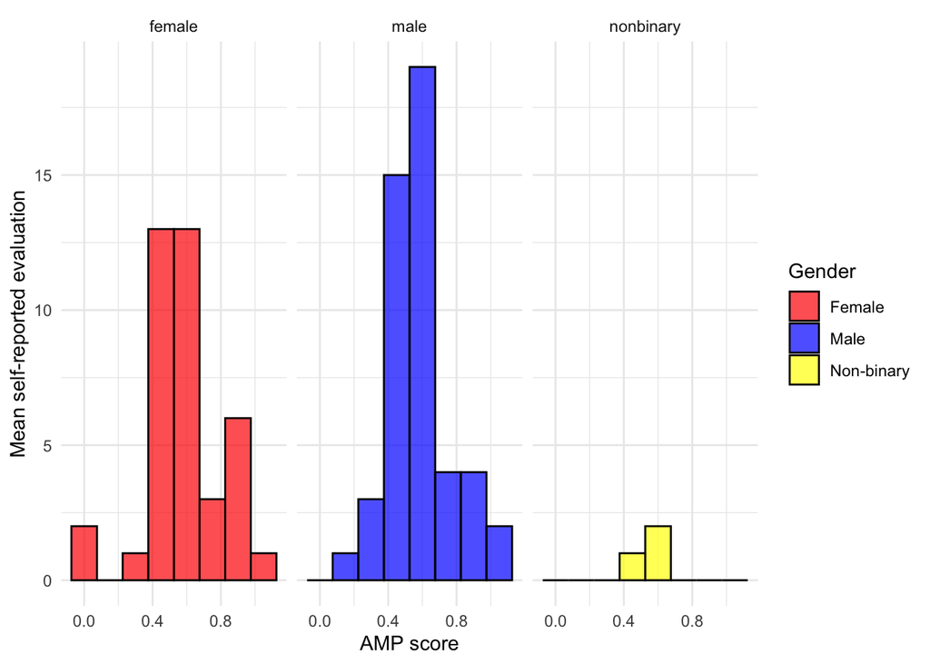

```r
ggplot(data_processed_after_exclusions, aes(x = AMP_score, fill = gender)) +
  geom_histogram(binwidth = 0.15, color = "black", alpha = 0.7) +
  facet_grid(. ~ gender) +
  scale_fill_manual(values = c("female" = "red", "male" = "blue", "nonbinary" = "yellow"),
                    labels = c("Female", "Male", "Non-binary")) +
  labs(x = "AMP score", y = "Mean self-reported evaluation", fill = "Gender") +
  theme_minimal()
```

### Test

run an appropriate test. Below the output, print an interpretation of the results generated by the ‘easystats’ package [report](https://easystats.github.io/report/). I.e., use `report::report()`.

```r
library(report)

filtered_data <- data_processed_after_exclusions |>
  filter(gender %in% c("male", "female"))

ttest_mean.eval_gender <- t.test(mean_evaluation ~ gender, data = filtered_data)
report(ttest_mean.eval_gender)
```

```
## Effect sizes were labelled following Cohen's (1988) recommendations.
##
## The Welch Two Sample t-test testing the difference of mean_evaluation by gender
## (mean in group female = 1.32, mean in group male = 1.81) suggests that the
## effect is negative, statistically significant, and medium (difference = -0.49,
## 95% CI [-0.86, -0.12], t(83.14) = -2.62, p = 0.011; Cohen's d = -0.57, 95% CI
## [-1.01, -0.13])
```

## Combining plots

Combine plots using patchwork: https://patchwork.data-imaginist.com/

Combine at least three of the above plots into one.

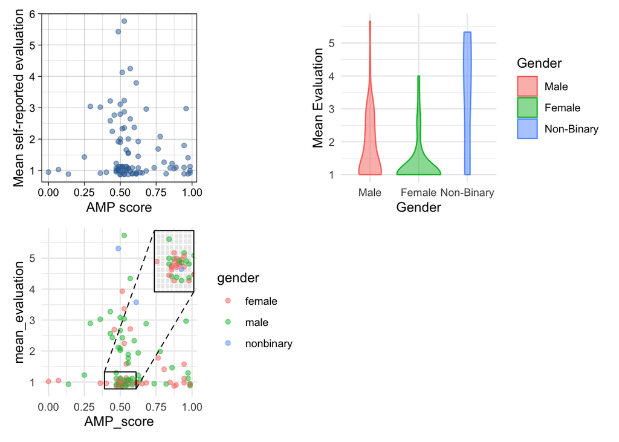

```r
library(patchwork)

p1 <- ggplot(data_processed_after_exclusions,
       aes(x = AMP_score,
           y = mean_evaluation)) +
  geom_jitter(color = viridis_pal(begin = 0.45, option = "mako")(1),
              alpha = 0.5) +
  xlab("AMP score") +
  ylab("Mean self-reported evaluation") +
  theme_linedraw()

p2 <- ggplot(data_processed_after_exclusions,
       aes(y = mean_evaluation,
           x = gender,
           fill = gender,
           color = gender)) +
  geom_violin(alpha = 0.5, size = 0.5) +
  scale_x_discrete(limits = c("male", "female", "nonbinary")) +
  scale_x_discrete(limits = c("male", "female", "nonbinary"),
                   labels = c("Male", "Female", "Non-Binary")) +
  scale_fill_discrete(limits = c("male", "female", "nonbinary"),
                      name = "Gender", labels=c("Male", "Female", "Non-Binary")) +
  scale_color_discrete(limits = c("male", "female", "nonbinary"),
                       name = "Gender", labels=c("Male", "Female", "Non-Binary")) +
  labs(x = "Gender", y = "Mean Evaluation") +
  theme_minimal()

p3 <- ggplot(data_processed_after_exclusions,
             aes(x = AMP_score,
             y = mean_evaluation,
             colour = gender)) +
    geom_jitter(alpha = 0.5) +
    geom_magnify(shape = "rect",
                 from = c(xmin = 0.4, xmax = 0.6, ymin = 0.8, ymax = 1.3 ),
                 to = c(xmin = 0.75, xmax = 1, ymin = 4, ymax = 5.8 )) +
    theme_minimal()

p1 + p2 + p3 +
  plot_layout(widths = c(2, 2))
```

## Saving plots

Save plots to disk with `ggsave()`

Save the above combined plot to disk as both .png and .pdf. Ensure the png has at least 300dpi resolution.

```r
ggsave("combined_plots.png", dpi = 300)
ggsave("combined_plots.pdf", dpi = 300)
```